# chapter5

**2. PCA**

```r
pca_hum<-prcomp(human) # PCA
s<-summary(pca_hum)
s
```

```
## Importance of components:
##                              PC1      PC2   PC3   PC4   PC5   PC6    PC7    PC8
## Standard deviation     1.854e+04 185.5219 25.19 11.45 3.766 1.566 0.1912 0.1591
## Proportion of Variance 9.999e-01   0.0001  0.00  0.00 0.000 0.000 0.0000 0.0000
## Cumulative Proportion  9.999e-01   1.0000  1.00  1.00 1.000 1.000 1.0000 1.0000
```

```r
pc_pr <- round(100*s$importance[2,], digits = 1)
pc_pr
```

```
## PC1 PC2 PC3 PC4 PC5 PC6 PC7 PC8
## 100   0   0   0   0   0   0   0
```

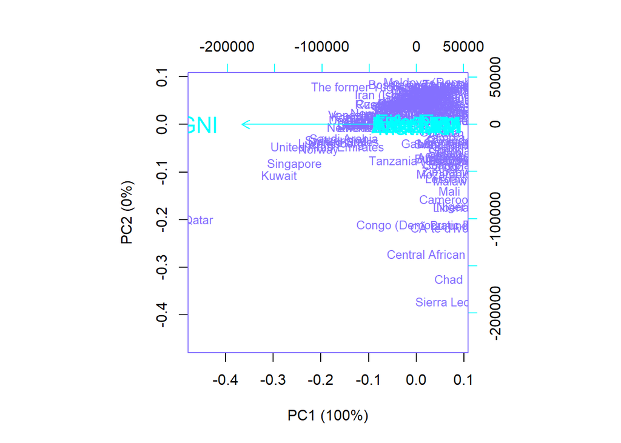

```r
pc_lab <- paste0(names(pc_pr), " (", pc_pr, "%)")
biplot(pca_hum, cex = c(0.8, 1.5), col = c("lightslateblue", "cyan1"), xlab = pc_lab[1], ylab = pc_lab[2])
```

Well, this seems quite strange. The scales are not the same. Here only one dimension explains all variances. Propably it is the GNI. But to interprete anything is quite difficult, even not possible I would say. Therefore, we need first to scale the data to have the same scale for all data.

**3. standardized PCA**

```r
human_std<-scale(human)
pca_human<-prcomp(human_std) # PCA
s1<-summary(pca_human)
s1
```

```
## Importance of components:
##                           PC1    PC2     PC3     PC4     PC5     PC6     PC7
## Standard deviation     2.0708 1.1397 0.87505 0.77886 0.66196 0.53631 0.45900
## Proportion of Variance 0.5361 0.1624 0.09571 0.07583 0.05477 0.03595 0.02634
## Cumulative Proportion  0.5361 0.6984 0.79413 0.86996 0.92473 0.96069 0.98702
##                            PC8
## Standard deviation     0.32224
## Proportion of Variance 0.01298
## Cumulative Proportion  1.00000
```

```r
pc_pr1 <- round(100*s1$importance[2,], digits = 1)
pc_pr1
```

```
##  PC1  PC2  PC3  PC4  PC5  PC6  PC7  PC8
## 53.6 16.2  9.6  7.6  5.5  3.6  2.6  1.3
```

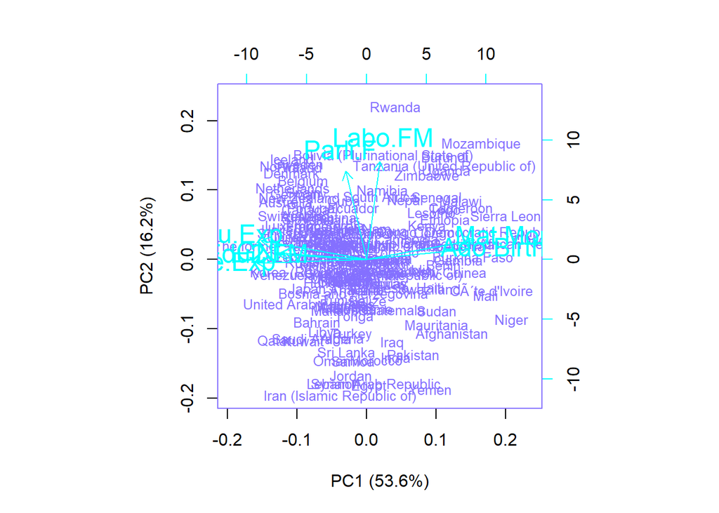

```r
pc_lab1 <- paste0(names(pc_pr1), " (", pc_pr1, "%)")
biplot(pca_human, cex = c(0.8, 1.5), col = c("lightslateblue", "cyan1"), xlab = pc_lab1[1], ylab = pc_lab1[2])
```

As described above, we cannot interpret the results without the same scale. Through scaling data are still the same, but we can now compare it. I would say the results may the same also PCA looked different because of the different scales. But only now we can make some correlations assumptions of these data. Probably, Parli F and Labo FM variables describe the PC2 whereas the other variables descirbe the other component.

**4. personal interpretation**

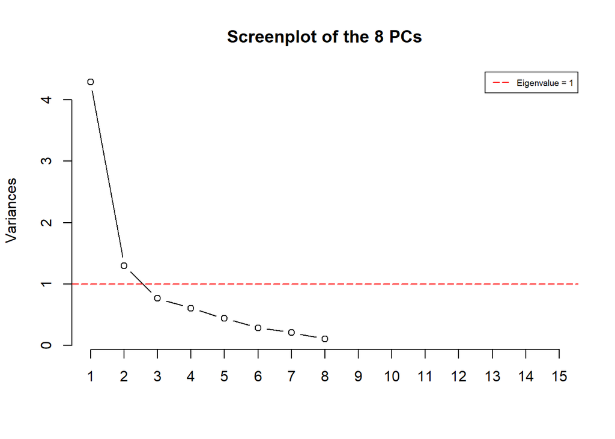

```r
screeplot(pca_human, type = "l", npcs = 15, main = "Screenplot of the 8 PCs")
abline(h = 1, col="red", lty=5)
legend("topright", legend=c("Eigenvalue = 1"),
       col=c("red"), lty=5, cex=0.6)
```

The standardized PCA shows that Maternal death rate and adolescent birth rate is strongly correlated/associated. Also Labo FM and Parli F. ALso the other 4 variables are correlated to each other (Edu2 FM, EDU Exp Life exp, GNI). But their arrows are around 180 degrees “away” from Mat. Mor. and Ado. Birth, it can be said that they are negatively correlated. All features which are horizontal located have almost no correlation to Labo FM and Parli F. Besides this, we can say that Martial Mort. and Ado birth contribute to PCA1 positivly and Labo FM and Parli F contribute positively to PCA2. Rwanda is a bit outside. that could be an outlier.

**5. MCA**

```r
library(FactoMineR)
data(tea)
str(tea)
```

```
## 'data.frame':    300 obs. of  36 variables:
##  $ breakfast       : Factor w/ 2 levels "breakfast","Not.breakfast": 1 1 2 2 1 2 1 2 1 1 ...
##  $ tea.time        : Factor w/ 2 levels "Not.tea time",..: 1 1 2 1 1 1 2 2 2 1 ...
##  $ evening         : Factor w/ 2 levels "evening","Not.evening": 2 2 1 2 1 2 2 1 2 1 ...
##  $ lunch           : Factor w/ 2 levels "lunch","Not.lunch": 2 2 2 2 2 2 2 2 2 2 ...
##  $ dinner          : Factor w/ 2 levels "dinner","Not.dinner": 2 2 1 1 2 1 2 2 2 2 ...
##  $ always          : Factor w/ 2 levels "always","Not.always": 2 2 2 2 1 2 2 2 2 2 ...
##  $ home            : Factor w/ 2 levels "home","Not.home": 1 1 1 1 1 1 1 1 1 1 ...
##  $ work            : Factor w/ 2 levels "Not.work","work": 1 1 2 1 1 1 1 1 1 1 ...
##  $ tearoom         : Factor w/ 2 levels "Not.tearoom",..: 1 1 1 1 1 1 1 1 1 2 ...
##  $ friends         : Factor w/ 2 levels "friends","Not.friends": 2 2 1 2 2 2 1 2 2 2 ...
##  $ resto           : Factor w/ 2 levels "Not.resto","resto": 1 1 2 1 1 1 1 1 1 1 ...
##  $ pub             : Factor w/ 2 levels "Not.pub","pub": 1 1 1 1 1 1 1 1 1 1 ...
##  $ Tea             : Factor w/ 3 levels "black","Earl Grey",..: 1 1 2 2 2 2 2 1 2 1 ...
##  $ How             : Factor w/ 4 levels "alone","lemon",..: 1 3 1 1 1 1 1 3 3 1 ...
```

[output cut: 22 more lines]

```r
dim(tea)
```

```
## [1] 300  36
```

```r
keep_columns <- c("Tea", "How", "how", "sugar", "where", "lunch") # keep the clomun
tea_time <- dplyr::select(tea, one_of(keep_columns))
summary(tea_time)
```

```
##         Tea         How                      how           sugar
##  black    : 74   alone:195   tea bag           :170   No.sugar:155
##  Earl Grey:193   lemon: 33   tea bag+unpackaged: 94   sugar   :145
##  green    : 33   milk : 63   unpackaged        : 36
##                  other:  9
##                   where           lunch
##  chain store         :192   lunch    : 44
##  chain store+tea shop: 78   Not.lunch:256
##  tea shop            : 30
##
```

```r
str(tea_time)
```

```
## 'data.frame':    300 obs. of  6 variables:
##  $ Tea  : Factor w/ 3 levels "black","Earl Grey",..: 1 1 2 2 2 2 2 1 2 1 ...
##  $ How  : Factor w/ 4 levels "alone","lemon",..: 1 3 1 1 1 1 1 3 3 1 ...
##  $ how  : Factor w/ 3 levels "tea bag","tea bag+unpackaged",..: 1 1 1 1 1 1 1 1 2 2 ...
##  $ sugar: Factor w/ 2 levels "No.sugar","sugar": 2 1 1 2 1 1 1 1 1 1 ...
##  $ where: Factor w/ 3 levels "chain store",..: 1 1 1 1 1 1 1 1 2 2 ...
##  $ lunch: Factor w/ 2 levels "lunch","Not.lunch": 2 2 2 2 2 2 2 2 2 2 ...
```

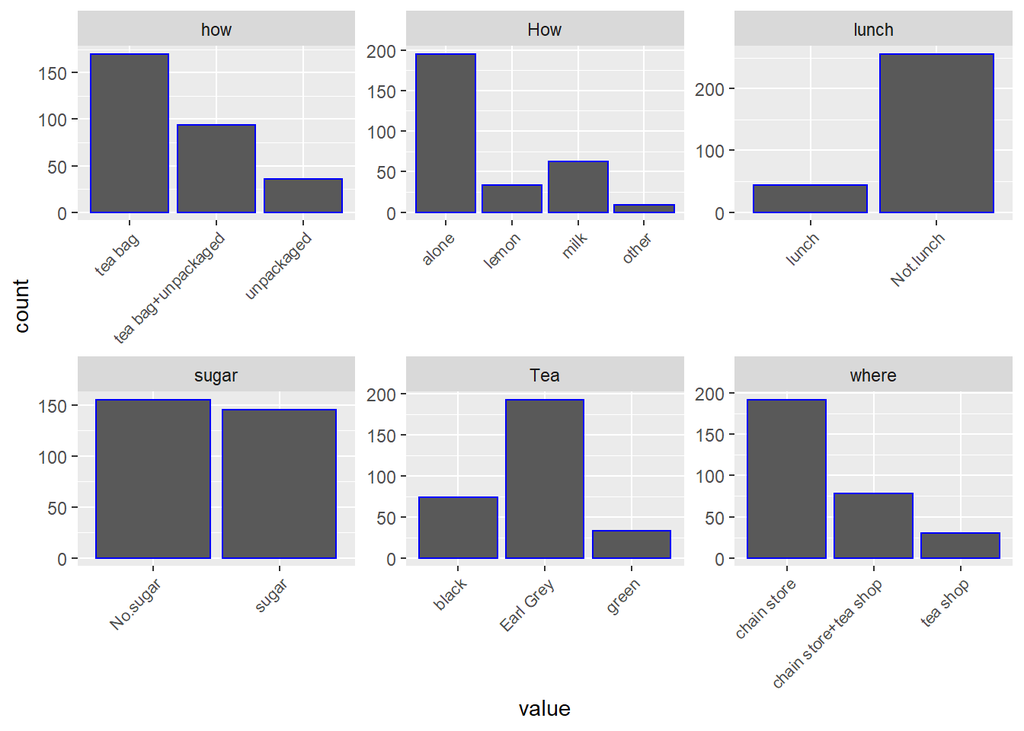

```r
gather(tea_time) %>% ggplot(aes(value)) + facet_wrap("key", scales = "free") + geom_bar(colour='blue') + theme(axis.text.x = element_text(angle = 45, hjust = 1, size = 8))
```

```r
mca <- MCA(tea_time, graph = FALSE) # MCA for catecorical variable
summary(mca)
```

```
##
## Call:
## MCA(X = tea_time, graph = FALSE)
##
##
## Eigenvalues
##                        Dim.1   Dim.2   Dim.3   Dim.4   Dim.5   Dim.6   Dim.7
## Variance               0.279   0.261   0.219   0.189   0.177   0.156   0.144
## % of var.             15.238  14.232  11.964  10.333   9.667   8.519   7.841
## Cumulative % of var.  15.238  29.471  41.435  51.768  61.434  69.953  77.794
##                        Dim.8   Dim.9  Dim.10  Dim.11
## Variance               0.141   0.117   0.087   0.062
## % of var.              7.705   6.392   4.724   3.385
## Cumulative % of var.  85.500  91.891  96.615 100.000
##
## Individuals (the 10 first)
##                       Dim.1    ctr   cos2    Dim.2    ctr   cos2    Dim.3
## 1                  | -0.298  0.106  0.086 | -0.328  0.137  0.105 | -0.327
## 2                  | -0.237  0.067  0.036 | -0.136  0.024  0.012 | -0.695
## 3                  | -0.369  0.162  0.231 | -0.300  0.115  0.153 | -0.202
## 4                  | -0.530  0.335  0.460 | -0.318  0.129  0.166 |  0.211
## 5                  | -0.369  0.162  0.231 | -0.300  0.115  0.153 | -0.202
## 6                  | -0.369  0.162  0.231 | -0.300  0.115  0.153 | -0.202
## 7                  | -0.369  0.162  0.231 | -0.300  0.115  0.153 | -0.202
## 8                  | -0.237  0.067  0.036 | -0.136  0.024  0.012 | -0.695
## 9                  |  0.143  0.024  0.012 |  0.871  0.969  0.435 | -0.067
## 10                 |  0.476  0.271  0.140 |  0.687  0.604  0.291 | -0.650
##                       ctr   cos2
## 1                   0.163  0.104 |
## 2                   0.735  0.314 |
## 3                   0.062  0.069 |
## 4                   0.068  0.073 |
## 5                   0.062  0.069 |
## 6                   0.062  0.069 |
## 7                   0.062  0.069 |
## 8                   0.735  0.314 |
## 9                   0.007  0.003 |
## 10                  0.643  0.261 |
##
## Categories (the 10 first)
```

[output cut: 16 more lines]

```
## lemon                3.226 |   1.329  14.771   0.218   8.081 |
## milk                 2.422 |   0.013   0.003   0.000   0.116 |
## other                5.534 |  -2.524  14.526   0.197  -7.676 |
## tea bag             -6.941 |  -0.065   0.183   0.006  -1.287 |
## tea bag+unpackaged  11.956 |   0.019   0.009   0.000   0.226 |
## unpackaged          -6.482 |   0.257   0.602   0.009   1.640 |
##
## Categorical variables (eta2)
##                      Dim.1 Dim.2 Dim.3
## Tea                | 0.126 0.108 0.410 |
## How                | 0.076 0.190 0.394 |
## how                | 0.708 0.522 0.010 |
## sugar              | 0.065 0.001 0.336 |
## where              | 0.702 0.681 0.055 |
## lunch              | 0.000 0.064 0.111 |
```

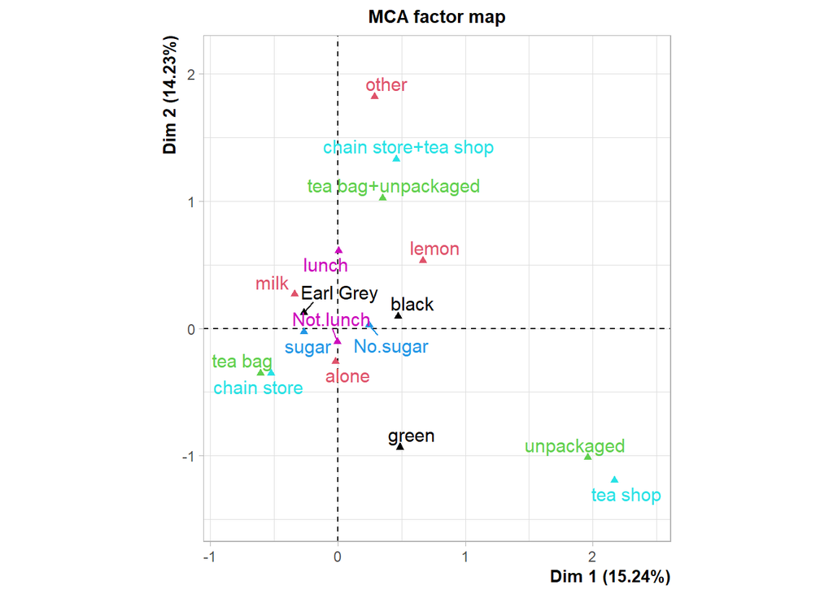

```r
plot(mca, invisible=c("ind"), habillage = "quali")
```

```r
#MCA plot for all data except age, because this is a continues variable
tea1<- subset(tea, select = -c(age)) # select function to drup 1 column
mca <- MCA(tea1, graph = FALSE)
summary(mca)
```

```
##
## Call:
## MCA(X = tea1, graph = FALSE)
##
##
## Eigenvalues
##                        Dim.1   Dim.2   Dim.3   Dim.4   Dim.5   Dim.6   Dim.7
## Variance               0.090   0.082   0.070   0.063   0.056   0.053   0.050
## % of var.              5.838   5.292   4.551   4.057   3.616   3.465   3.272
## Cumulative % of var.   5.838  11.130  15.681  19.738  23.354  26.819  30.091
##                        Dim.8   Dim.9  Dim.10  Dim.11  Dim.12  Dim.13  Dim.14
## Variance               0.048   0.047   0.044   0.041   0.040   0.039   0.037
## % of var.              3.090   3.053   2.834   2.643   2.623   2.531   2.388
## Cumulative % of var.  33.181  36.234  39.068  41.711  44.334  46.865  49.252
##                       Dim.15  Dim.16  Dim.17  Dim.18  Dim.19  Dim.20  Dim.21
## Variance               0.036   0.035   0.034   0.032   0.031   0.031   0.030
## % of var.              2.302   2.275   2.172   2.085   2.013   2.011   1.915
## Cumulative % of var.  51.554  53.829  56.000  58.086  60.099  62.110  64.025
##                       Dim.22  Dim.23  Dim.24  Dim.25  Dim.26  Dim.27  Dim.28
## Variance               0.028   0.027   0.026   0.025   0.025   0.024   0.024
## % of var.              1.847   1.740   1.686   1.638   1.609   1.571   1.524
## Cumulative % of var.  65.872  67.611  69.297  70.935  72.544  74.115  75.639
##                       Dim.29  Dim.30  Dim.31  Dim.32  Dim.33  Dim.34  Dim.35
## Variance               0.023   0.022   0.021   0.020   0.020   0.019   0.019
## % of var.              1.459   1.425   1.378   1.322   1.281   1.241   1.222
## Cumulative % of var.  77.099  78.523  79.901  81.223  82.504  83.745  84.967
##                       Dim.36  Dim.37  Dim.38  Dim.39  Dim.40  Dim.41  Dim.42
## Variance               0.018   0.017   0.017   0.016   0.015   0.015   0.014
## % of var.              1.152   1.092   1.072   1.019   0.993   0.950   0.924
## Cumulative % of var.  86.119  87.211  88.283  89.301  90.294  91.244  92.169
##                       Dim.43  Dim.44  Dim.45  Dim.46  Dim.47  Dim.48  Dim.49
## Variance               0.014   0.013   0.012   0.011   0.011   0.010   0.010
## % of var.              0.891   0.833   0.792   0.729   0.716   0.666   0.660
## Cumulative % of var.  93.060  93.893  94.684  95.414  96.130  96.796  97.456
##                       Dim.50  Dim.51  Dim.52  Dim.53  Dim.54
## Variance               0.009   0.009   0.008   0.007   0.006
## % of var.              0.605   0.584   0.519   0.447   0.390
## Cumulative % of var.  98.060  98.644  99.163  99.610 100.000
##
## Individuals (the 10 first)
```

[output cut: 44 more lines]

```
## dinner         0.796  1.805  0.048  3.777 |
## Not.dinner    -0.060  0.136  0.048 -3.777 |
##
## Categorical variables (eta2)
##                 Dim.1 Dim.2 Dim.3
## breakfast     | 0.031 0.000 0.011 |
## tea.time      | 0.240 0.000 0.003 |
## evening       | 0.040 0.087 0.062 |
## lunch         | 0.062 0.029 0.010 |
## dinner        | 0.092 0.000 0.048 |
## always        | 0.056 0.035 0.007 |
## home          | 0.016 0.002 0.030 |
## work          | 0.075 0.020 0.022 |
## tearoom       | 0.321 0.019 0.031 |
## friends       | 0.186 0.061 0.030 |
```

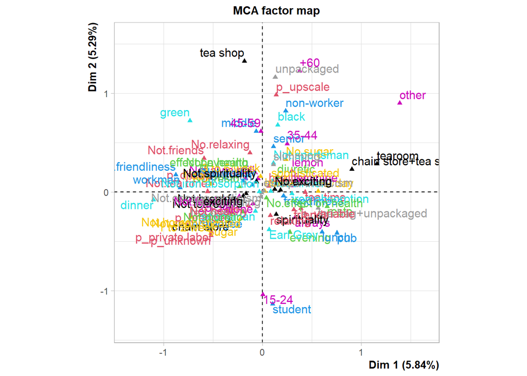

```r
plot(mca, invisible=c("ind"), habillage = "quali")
```

The tea data set is about tea. 300 individuals were asked how they drink tea (18 questions), what are their product’s perception (12 questions) and some personal details (4 questions). Here we have kept the Tea (which tea), How (without something, with something, if yes what), how (tea bag, unpacked or both), lunch(dringing at lunch yes or no), sugar(yes or no) and where(where to buy it). We can say that in overall, most people take tea bags, drinking earl gray, mostly pure and not during lunch time. The sugar intake is slightly lower than without sugar and more people buy it in a chain store.

The Multiple Correspondence Analysis analysis the pattern of relationships of several categorical variables. First we see the Eigenvalues: It shows the percentage of explained variances of each Dimensions. So has Dimension 1 15.24 % of the explained variance. The individuals shows the coordinates of the first 10 variables, but also the contribution to the construction of the axis(in percentage), squared correlation (cos2), which represents the quality of the representation. The contribution is quite small because we have 300 observations. The first 3 dimensions are displayed. For our out, we can say that the first individual has the coordination of -0,298, with a contribution of 0.106 and squared correlation of 0.086. Next we have the results of the categories. The output shows the coordinates, the contribution nd the cos2 and the v.test for all categories (ok, here they show only the first 10 rows). The v. test follows normal distribution and can be seen as significant from 0 if the values are above 2 (1.96) or below -2 (1.96). For the category black we have a significance in dimension1 (4.677) and dimension3 (-10.692) but not for the second dimension (0.929) The last tables shows the squared correlation of the categorical variable(~R2). If the value is close to 1 it has a strong correlation to that dimension. For example: how has the strongest correlation of all in dimension 1 with a value of 0.708. The weeks and actually absolutely no correlation has lunch with the dimension 1.

The first tea-time factor map shows the kept variables. We can say that between Earl Gray and milk but also sugar there is a similarity. So it seems that people who drink Earl gray (also most nothing in their tea) if they use milk then in Earl gray. An no sugar is more common in black than than in Earl gray. It is also shown that between unpacked tea and tea shop there is a similarity because these categories are closer. So people buys unpacked tea in tea shops. Whereas, teabags are bought in chain stores more often. Green tea is a bit special. It stays alone. But it has more similarities with a chain store than a tea shop but just minor differences (distances).

The second plot shows all categorical variables and their similarities. Here, it shows that Earl Grey has similarities with evenings. So they might drink more in the evenings. lunch and pub are very close. So mybe pople if the drink tea at lunch time than in a pup. Students are in the groups of 15-24 but they are not are otherwise far from the other variables. Maybe there were not so many individuals in that data set or the don’t drink so ,uch tea.

[figure not shown]

whoop whoop, it still makes fun :)